# Module 178

#### Contrast SVE:

Signed variance explained (SVE) provides an indication of how similar a set of fold changes are to a gene module’s weight vector. An SVE value of 0.3, for example, indicates that 30% of the variance explained by the entire module set is accounted for by the module in question. Shown here are the SVE values for this module across a compendium of fold changes (contrasts). Extreme SVE values (e.g., > 0.05) indicate that those contrasts specifically induce (orange dots) or specifically repress (blue dots) this module. Examining the experimental conditions being compared in such contrasts (see tables below the figure) may provide insight into the gene module’s function.

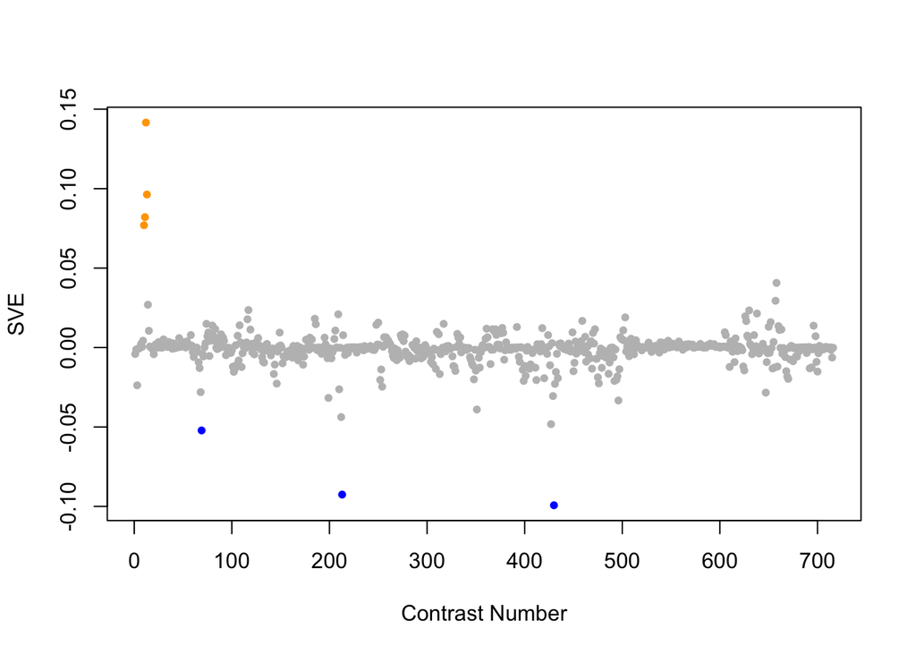

Positive SVE Contrasts:

|  | Contrast.Num | SVE | GEO.GSE | Cond.1 | Cond.2 | Mutation |
| --- | --- | --- | --- | --- | --- | --- |
| GSE9682.s1t2.vs.s0t2 | 12 | 0.14 | GSE9682 | N2-Cel-RhebRNAi-fed-biological rep1 | N2-controlRNAi-fed-biological rep1 | Rheb |
| GSE9682.s2t2.vs.s0t2 | 13 | 0.10 | GSE9682 | N2-Cel-TORRNAi-fed-biological rep1 | N2-controlRNAi-fed-biological rep1 | TOR |
| GSE9682.s2t1.vs.s0t1 | 11 | 0.08 | GSE9682 | N2-Cel-TORRNAi-fasting-biological rep1 | N2-controlRNAi-fasting-biological rep1 | TOR |
| GSE9682.s1t1.vs.s0t1 | 10 | 0.08 | GSE9682 | N2-Cel-RhebRNAi-fasting-biological rep1 | N2-controlRNAi-fasting-biological rep1 | Rheb |
| GSE16050.s0t2.vs.s0t1 | 658 | 0.04 | GSE16050 | WT_GFPm_rep1 | WT_GFPp_rep1 |  |

Negative SVE Contrasts:

|  | Contrast.Num | SVE | GEO.GSE | Cond.1 | Cond.2 | Mutation |
| --- | --- | --- | --- | --- | --- | --- |
| GSE27677A.s1t1.vs.s0t1 | 430 | -0.10 | GSE27677 | kgb-1, Fed , rep 1 | N2, Fed , rep 1 | kgb-1 |
| GSE42689.s4t1.vs.s2t1 | 213 | -0.09 | GSE42689 | mlk-1 fed 1 | mek-1 fed 1 |  |
| GSE8462.s2t2.vs.s1t2 | 69 | -0.05 | GSE8462 | 24 hr Reference, biological rep 1 | 24 hr muscle, biological rep 1 |  |
| GSE27677A.s1t2.vs.s0t2 | 427 | -0.05 | GSE27677 | kgb-1, Fast , rep 1 | N2, Fast , rep 1 | kgb-1 |
| GSE42689.s3t1.vs.s2t1 | 212 | -0.04 | GSE42689 | mlk-1 fasted 1 | mek-1 fed 1 |  |

$~$

#### Contrast SVE, Up-Regulated Genes Only:

Calculating SVE for up-regulated and down-regulated genes separately may be more informative in many cases than projecting the up- and down- gene sets together. This is due to the fact that the weight distribution of many modules is highly skewed, indicating that only one of the hemi-modules may be biologically meaningful (i.e., a set of genes are strongly correlated by only a few genes (or none) are strongly anti-correlated to that set.)

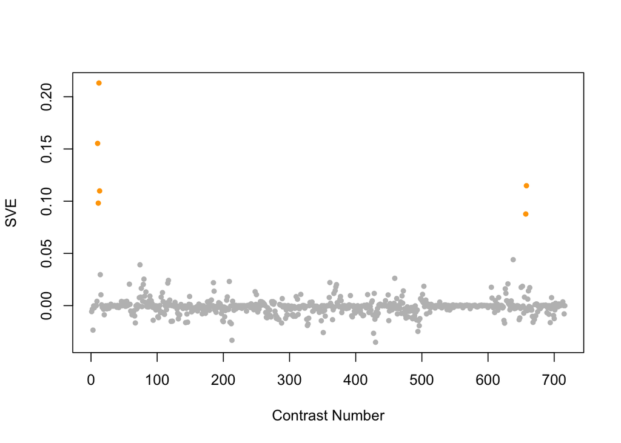

Positive SVE Contrasts:

|  | Contrast.Num | SVE | GEO.GSE | Cond.1 | Cond.2 | Mutation |
| --- | --- | --- | --- | --- | --- | --- |
| GSE9682.s1t2.vs.s0t2 | 12 | 0.21 | GSE9682 | N2-Cel-RhebRNAi-fed-biological rep1 | N2-controlRNAi-fed-biological rep1 | Rheb |
| GSE9682.s1t1.vs.s0t1 | 10 | 0.16 | GSE9682 | N2-Cel-RhebRNAi-fasting-biological rep1 | N2-controlRNAi-fasting-biological rep1 | Rheb |
| GSE16050.s0t2.vs.s0t1 | 658 | 0.11 | GSE16050 | WT_GFPm_rep1 | WT_GFPp_rep1 |  |
| GSE9682.s2t2.vs.s0t2 | 13 | 0.11 | GSE9682 | N2-Cel-TORRNAi-fed-biological rep1 | N2-controlRNAi-fed-biological rep1 | TOR |
| GSE9682.s2t1.vs.s0t1 | 11 | 0.10 | GSE9682 | N2-Cel-TORRNAi-fasting-biological rep1 | N2-controlRNAi-fasting-biological rep1 | TOR |
| GSE16050.s1t2.vs.s1t1 | 657 | 0.09 | GSE16050 | MT_GFPm_rep1 | MT_GFPp_rep1 |  |

Negative SVE Contrasts:

|  | Contrast.Num | SVE | GEO.GSE | Cond.1 | Cond.2 | Mutation |
| --- | --- | --- | --- | --- | --- | --- |
| GSE27677A.s1t1.vs.s0t1 | 430 | -0.04 | GSE27677 | kgb-1, Fed , rep 1 | N2, Fed , rep 1 | kgb-1 |
| GSE42689.s4t1.vs.s2t1 | 213 | -0.03 | GSE42689 | mlk-1 fed 1 | mek-1 fed 1 |  |
| GSE27677A.s1t2.vs.s0t2 | 427 | -0.03 | GSE27677 | kgb-1, Fast , rep 1 | N2, Fast , rep 1 | kgb-1 |
| GSE38997.s3t4.vs.s3t1 | 351 | -0.03 | GSE38997 | experiment 1 UVC- and EtBr-exposed samples at 51 h 1eu51 | experiment 4 UVC- and EtBr-exposed samples at 3 h 4eu3 |  |
| GSE23528C.s1t3.vs.s1t1 | 494 | -0.02 | GSE23528 | Adult at T34 in DD, time-series experiment 2 | Adult at T26 in DD, time-series experiment 2 |  |

$~$

#### Contrast SVE, Down-Regulated Genes Only:

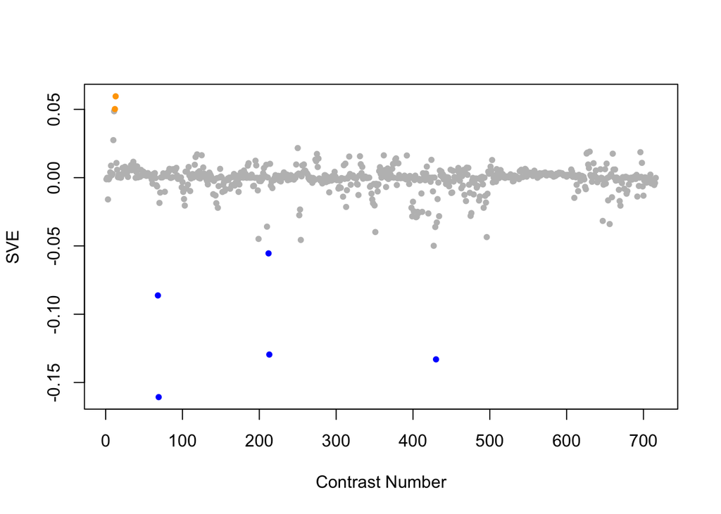

Positive SVE Contrasts:

|  | Contrast.Num | SVE | GEO.GSE | Cond.1 | Cond.2 | Mutation |
| --- | --- | --- | --- | --- | --- | --- |
| GSE9682.s2t2.vs.s0t2 | 13 | 0.06 | GSE9682 | N2-Cel-TORRNAi-fed-biological rep1 | N2-controlRNAi-fed-biological rep1 | TOR |
| GSE9682.s1t2.vs.s0t2 | 12 | 0.05 | GSE9682 | N2-Cel-RhebRNAi-fed-biological rep1 | N2-controlRNAi-fed-biological rep1 | Rheb |
| GSE9682.s2t1.vs.s0t1 | 11 | 0.05 | GSE9682 | N2-Cel-TORRNAi-fasting-biological rep1 | N2-controlRNAi-fasting-biological rep1 | TOR |
| GSE9682.s1t1.vs.s0t1 | 10 | 0.03 | GSE9682 | N2-Cel-RhebRNAi-fasting-biological rep1 | N2-controlRNAi-fasting-biological rep1 | Rheb |
| GSE42192.s1t1.vs.s0t1 | 250 | 0.02 | GSE42192 | C.elegans fed with CNCM I-3690 3 days rep1 | C.elegans fed with E.coli OP50 3 days rep1 |  |

Negative SVE Contrasts:

|  | Contrast.Num | SVE | GEO.GSE | Cond.1 | Cond.2 | Mutation |
| --- | --- | --- | --- | --- | --- | --- |
| GSE8462.s2t2.vs.s1t2 | 69 | -0.16 | GSE8462 | 24 hr Reference, biological rep 1 | 24 hr muscle, biological rep 1 |  |
| GSE27677A.s1t1.vs.s0t1 | 430 | -0.13 | GSE27677 | kgb-1, Fed , rep 1 | N2, Fed , rep 1 | kgb-1 |
| GSE42689.s4t1.vs.s2t1 | 213 | -0.13 | GSE42689 | mlk-1 fed 1 | mek-1 fed 1 |  |
| GSE8462.s2t1.vs.s1t1 | 68 | -0.09 | GSE8462 | 0 hr Reference, biological rep 1 | 0 hr muscle, biological rep 1 |  |
| GSE42689.s3t1.vs.s2t1 | 212 | -0.06 | GSE42689 | mlk-1 fasted 1 | mek-1 fed 1 |  |

$~$

$~$

#### GO Term Enrichment:

This analysis tests each hemi-module for enrichment of specific GO terms. Only gene-level annotations (e.g., as would be found on the gene’s page in Wormbase) are tested - the hierarchical structure of the GO ontology is not taken into account.

*Note: At least the top two most enriched terms from each GO domain (BP/MF/CC) are shown, even when not statistically significant.*

##### Enriched GO terms: Hemi-module A

| ID | GO.Term | GO Domain | Raw p-value | Adj p-value |
| --- | --- | --- | --- | --- |
| [GO_0006936](http://amigo.geneontology.org/amigo/term/GO:0006936) | muscle contraction | BP | 1.94e-10 | 7.05e-07 |
| [GO_0010951](http://amigo.geneontology.org/amigo/term/GO:0010951) | negative regulation of endopeptidase activity | BP | 1.55e-07 | 2.82e-04 |
| [GO_0045214](http://amigo.geneontology.org/amigo/term/GO:0045214) | sarcomere organization | BP | 3.49e-06 | 4.23e-03 |
| [GO_0030241](http://amigo.geneontology.org/amigo/term/GO:0030241) | skeletal muscle myosin thick filament assembly | BP | 1.02e-05 | 7.44e-03 |
| [GO_0061061](http://amigo.geneontology.org/amigo/term/GO:0061061) | muscle structure development | BP | 1.02e-05 | 7.44e-03 |
| [GO_0060298](http://amigo.geneontology.org/amigo/term/GO:0060298) | positive regulation of sarcomere organization | BP | 1.59e-05 | 9.63e-03 |
| [GO_0045989](http://amigo.geneontology.org/amigo/term/GO:0045989) | positive regulation of striated muscle contraction | BP | 2.53e-05 | 1.32e-02 |
| [GO_0040011](http://amigo.geneontology.org/amigo/term/GO:0040011) | locomotion | BP | 2.08e-04 | 9.49e-02 |
| [GO_0003779](http://amigo.geneontology.org/amigo/term/GO:0003779) | actin binding | MF | 1.15e-09 | 2.34e-06 |
| [GO_0051015](http://amigo.geneontology.org/amigo/term/GO:0051015) | actin filament binding | MF | 2.55e-06 | 1.69e-03 |
| [GO_0051371](http://amigo.geneontology.org/amigo/term/GO:0051371) | muscle alpha-actinin binding | MF | 2.58e-06 | 1.69e-03 |
| [GO_0005509](http://amigo.geneontology.org/amigo/term/GO:0005509) | calcium ion binding | MF | 3.30e-06 | 1.69e-03 |
| [GO_0004867](http://amigo.geneontology.org/amigo/term/GO:0004867) | serine-type endopeptidase inhibitor activity | MF | 1.03e-05 | 4.20e-03 |
| [GO_0005201](http://amigo.geneontology.org/amigo/term/GO:0005201) | extracellular matrix structural constituent | MF | 4.27e-05 | 1.46e-02 |
| [GO_0008307](http://amigo.geneontology.org/amigo/term/GO:0008307) | structural constituent of muscle | MF | 5.00e-05 | 1.46e-02 |
| [GO_0008289](http://amigo.geneontology.org/amigo/term/GO:0008289) | lipid binding | MF | 3.14e-04 | 8.01e-02 |
| [GO_0003677](http://amigo.geneontology.org/amigo/term/GO:0003677) | DNA binding | MF | 3.73e-04 | 8.46e-02 |
| [GO_0005615](http://amigo.geneontology.org/amigo/term/GO:0005615) | extracellular space | CC | 4.87e-16 | 4.51e-13 |
| [GO_0005604](http://amigo.geneontology.org/amigo/term/GO:0005604) | basement membrane | CC | 1.60e-14 | 7.40e-12 |
| [GO_0005576](http://amigo.geneontology.org/amigo/term/GO:0005576) | extracellular region | CC | 7.22e-13 | 2.23e-10 |
| [GO_0031672](http://amigo.geneontology.org/amigo/term/GO:0031672) | A band | CC | 5.11e-10 | 1.19e-07 |
| [GO_0055120](http://amigo.geneontology.org/amigo/term/GO:0055120) | striated muscle dense body | CC | 5.73e-09 | 1.06e-06 |
| [GO_0005634](http://amigo.geneontology.org/amigo/term/GO:0005634) | nucleus | CC | 1.34e-08 | 2.07e-06 |
| [GO_0005865](http://amigo.geneontology.org/amigo/term/GO:0005865) | striated muscle thin filament | CC | 5.67e-08 | 7.52e-06 |
| [GO_0016021](http://amigo.geneontology.org/amigo/term/GO:0016021) | integral component of membrane | CC | 3.66e-07 | 4.25e-05 |
| [GO_0016020](http://amigo.geneontology.org/amigo/term/GO:0016020) | membrane | CC | 4.47e-07 | 4.61e-05 |
| [GO_0030016](http://amigo.geneontology.org/amigo/term/GO:0030016) | myofibril | CC | 5.54e-07 | 5.14e-05 |
| [GO_0031430](http://amigo.geneontology.org/amigo/term/GO:0031430) | M band | CC | 2.84e-06 | 2.40e-04 |
| [GO_0005861](http://amigo.geneontology.org/amigo/term/GO:0005861) | troponin complex | CC | 6.88e-06 | 5.32e-04 |
| [GO_0031012](http://amigo.geneontology.org/amigo/term/GO:0031012) | extracellular matrix | CC | 1.41e-05 | 1.00e-03 |
| [GO_0016459](http://amigo.geneontology.org/amigo/term/GO:0016459) | myosin complex | CC | 1.62e-05 | 1.00e-03 |
| [GO_0030017](http://amigo.geneontology.org/amigo/term/GO:0030017) | sarcomere | CC | 1.62e-05 | 1.00e-03 |
| [GO_0001725](http://amigo.geneontology.org/amigo/term/GO:0001725) | stress fiber | CC | 5.00e-05 | 2.73e-03 |
| [GO_0032982](http://amigo.geneontology.org/amigo/term/GO:0032982) | myosin filament | CC | 5.00e-05 | 2.73e-03 |
| [GO_0016529](http://amigo.geneontology.org/amigo/term/GO:0016529) | sarcoplasmic reticulum | CC | 9.19e-05 | 4.74e-03 |
| [GO_0005863](http://amigo.geneontology.org/amigo/term/GO:0005863) | striated muscle myosin thick filament | CC | 1.37e-04 | 6.37e-03 |
| [GO_0030018](http://amigo.geneontology.org/amigo/term/GO:0030018) | Z disc | CC | 1.37e-04 | 6.37e-03 |
| [GO_0099503](http://amigo.geneontology.org/amigo/term/GO:0099503) | secretory vesicle | CC | 1.89e-04 | 8.36e-03 |
| [GO_0031674](http://amigo.geneontology.org/amigo/term/GO:0031674) | I band | CC | 2.88e-04 | 1.22e-02 |
| [GO_0005859](http://amigo.geneontology.org/amigo/term/GO:0005859) | muscle myosin complex | CC | 5.62e-04 | 2.27e-02 |
| [GO_0015629](http://amigo.geneontology.org/amigo/term/GO:0015629) | actin cytoskeleton | CC | 1.81e-03 | 6.83e-02 |
| [GO_0042383](http://amigo.geneontology.org/amigo/term/GO:0042383) | sarcolemma | CC | 1.84e-03 | 6.83e-02 |
| [GO_0005913](http://amigo.geneontology.org/amigo/term/GO:0005913) | cell-cell adherens junction | CC | 2.47e-03 | 8.83e-02 |

##### Enriched GO terms: Hemi-module B

| ID | GO.Term | GO Domain | Raw p-value | Adj p-value |
| --- | --- | --- | --- | --- |
| [GO_0009062](http://amigo.geneontology.org/amigo/term/GO:0009062) | fatty acid catabolic process | BP | 5.58e-04 | 1.00e+00 |
| [GO_0006637](http://amigo.geneontology.org/amigo/term/GO:0006637) | acyl-CoA metabolic process | BP | 7.49e-04 | 1.00e+00 |
| [GO_0047617](http://amigo.geneontology.org/amigo/term/GO:0047617) | acyl-CoA hydrolase activity | MF | 6.50e-04 | 9.33e-01 |
| [GO_0016705](http://amigo.geneontology.org/amigo/term/GO:0016705) | oxidoreductase activity, acting on paired donors, with incorporation or reduction of molecular oxygen | MF | 1.34e-03 | 9.33e-01 |
| [GO_0005782](http://amigo.geneontology.org/amigo/term/GO:0005782) | peroxisomal matrix | CC | 3.95e-04 | 3.67e-01 |
| [GO_0030688](http://amigo.geneontology.org/amigo/term/GO:0030688) | preribosome, small subunit precursor | CC | 2.44e-02 | 1.00e+00 |

$~$

$~$

#### Tissue Enrichment:

This analysis tests each hemi-module for enrichment of genes associated with anatomy terms. Negative enrichment scores indicate fewer hemi-module genes than expected by random chance were associated with the anatomy term in question.

##### Enriched tissues: Hemi-module A

| ID | Anatomy.Term | Definition | Raw p-value | Adj p-value |
| --- | --- | --- | --- | --- |
| [WBbt_0005813](https://wormbase.org/species/all/anatomy_term/WBbt:0005813) | body wall musculature | Longitudinal bands of muscle cells surrounding animal body, with one band running in each quadrant of the body, regulated contraction and relaxation of these muscles cause locomotion. | 3.15e-27 | 7.67e-24 |
| [WBbt_0004292](https://wormbase.org/species/all/anatomy_term/WBbt:0004292) | anal depressor muscle | a single, H-shaped cell which lies just above the anus and connects the roof of the anal canal to the dorsal bodywall; its contractions act to increase the size of the anal opening by lifting the roof… | 3.38e-15 | 4.11e-12 |
| [WBbt_0005821](https://wormbase.org/species/all/anatomy_term/WBbt:0005821) | vulval muscle | muscle associated with hermaphrodite vulva. | 8.93e-15 | 7.24e-12 |
| [WBbt_0005796](https://wormbase.org/species/all/anatomy_term/WBbt:0005796) | intestinal muscle | intestinal muscle cell, attach to intestine and body wall anterior to anus | 4.57e-12 | 2.78e-09 |
| [WBbt_0005798](https://wormbase.org/species/all/anatomy_term/WBbt:0005798) | anal sphincter muscle | a saddle-shaped muscle cell that encircles the intestinal-rectal valve | 8.25e-09 | 4.01e-06 |
| [WBbt_0004781](https://wormbase.org/species/all/anatomy_term/WBbt:0004781) | GLRVR | Set of six cells that form a thin cylindrical sheet between pharynx and ring neuropile; no chemical synapses, but gap junctions with muscle arms and RME motor neurons | 3.80e-05 | 1.32e-02 |
| [WBbt_0004782](https://wormbase.org/species/all/anatomy_term/WBbt:0004782) | GLRVL | Set of six cells that form a thin cylindrical sheet between pharynx and ring neuropile; no chemical synapses, but gap junctions with muscle arms and RME motor neurons | 3.80e-05 | 1.32e-02 |
| [WBbt_0005803](https://wormbase.org/species/all/anatomy_term/WBbt:0005803) | rectal muscle | muscle that controls hermaphrodite rectal opening. | 4.78e-05 | 1.37e-02 |
| [WBbt_0004785](https://wormbase.org/species/all/anatomy_term/WBbt:0004785) | GLRDR | Set of six cells that form a thin cylindrical sheet between pharynx and ring neuropile; no chemical synapses, but gap junctions with muscle arms and RME motor neurons | 5.62e-05 | 1.37e-02 |
| [WBbt_0004786](https://wormbase.org/species/all/anatomy_term/WBbt:0004786) | GLRDL | Set of six cells that form a thin cylindrical sheet between pharynx and ring neuropile; no chemical synapses, but gap junctions with muscle arms and RME motor neurons | 5.62e-05 | 1.37e-02 |
| [WBbt_0004783](https://wormbase.org/species/all/anatomy_term/WBbt:0004783) | GLRR | Set of six cells that form a thin cylindrical sheet between pharynx and ring neuropile; no chemical synapses, but gap junctions with muscle arms and RME motor neurons | 1.10e-04 | 2.24e-02 |
| [WBbt_0004784](https://wormbase.org/species/all/anatomy_term/WBbt:0004784) | GLRL | Set of six cells that form a thin cylindrical sheet between pharynx and ring neuropile; no chemical synapses, but gap junctions with muscle arms and RME motor neurons | 1.10e-04 | 2.24e-02 |
| [WBbt_0005451](https://wormbase.org/species/all/anatomy_term/WBbt:0005451) | pharyngeal muscle cell | type of cells that make up muscle layers in the pharynx. | 1.26e-04 | 2.29e-02 |
| [WBbt_0005756](https://wormbase.org/species/all/anatomy_term/WBbt:0005756) | basal lamina |  | 1.32e-04 | 2.29e-02 |
| [WBbt_0006909](https://wormbase.org/species/all/anatomy_term/WBbt:0006909) | longitudinal male muscle | specialized muscle type in the posterior of adult male. | 1.48e-04 | 2.40e-02 |

##### Enriched tissues: Hemi-module B

No significant annotations.

$~$

$~$

#### HOMER promoter motif enrichment:

This analysis tests each hemi-module for enrichment of 108 known *C. elegans* transcription factor binding site motifs (see [108 CE motifs](https://katiepod.github.io//all.worm.motifs.html)) using the HOMER (Hypergeometric Optimization of Motif EnRichment) software (see [PMID:20513432](https://pubmed.ncbi.nlm.nih.gov/20513432)). HOMER was run using default parameters on sequences 1 kb upstream of the transcription start site.

##### Motif enrichment: Hemi-module A

Total target sequences = 217  
Total background sequences = 41108  
* - possible false positive

Rank

Motif

P-value

log P-pvalue

% of Targets

% of Background

STD(Bg STD)

Best Match/Details

Motif File

1

[figure not shown]

1e-14

-3.259e+01

10.60%

1.20%

248.0bp (327.5bp)

POL011.1_XCPE1/Jaspar(0.711)  
[More Information](https://katiepod.github.io/HomerResults/m178_a_hemi_genes.txt.out.1kb/homerResults/motif1.info.html) | [Similar Motifs Found](https://katiepod.github.io/HomerResults/m178_a_hemi_genes.txt.out.1kb/homerResults/motif1.similar.html)

[motif file (matrix)](https://katiepod.github.io/HomerResults/m178_a_hemi_genes.txt.out.1kb/homerResults/motif1.motif)

2

[figure not shown]

1e-12

-2.894e+01

13.82%

2.64%

325.3bp (334.8bp)

HLH-1(bHLH)/cElegans-Embryo-HLH1-ChIP-Seq(modEncode)/Homer(0.885)  
[More Information](https://katiepod.github.io/HomerResults/m178_a_hemi_genes.txt.out.1kb/homerResults/motif2.info.html) | [Similar Motifs Found](https://katiepod.github.io/HomerResults/m178_a_hemi_genes.txt.out.1kb/homerResults/motif2.similar.html)

[motif file (matrix)](https://katiepod.github.io/HomerResults/m178_a_hemi_genes.txt.out.1kb/homerResults/motif2.motif)

3

[figure not shown]

1e-12

-2.787e+01

4.15%

0.08%

240.3bp (351.8bp)

ceh-22/MA0264.1/Jaspar(0.591)  
[More Information](https://katiepod.github.io/HomerResults/m178_a_hemi_genes.txt.out.1kb/homerResults/motif3.info.html) | [Similar Motifs Found](https://katiepod.github.io/HomerResults/m178_a_hemi_genes.txt.out.1kb/homerResults/motif3.similar.html)

[motif file (matrix)](https://katiepod.github.io/HomerResults/m178_a_hemi_genes.txt.out.1kb/homerResults/motif3.motif)

4 *

[figure not shown]

1e-11

-2.743e+01

11.06%

1.72%

250.8bp (326.0bp)

eor-1/MA0543.1/Jaspar(0.769)  
[More Information](https://katiepod.github.io/HomerResults/m178_a_hemi_genes.txt.out.1kb/homerResults/motif4.info.html) | [Similar Motifs Found](https://katiepod.github.io/HomerResults/m178_a_hemi_genes.txt.out.1kb/homerResults/motif4.similar.html)

[motif file (matrix)](https://katiepod.github.io/HomerResults/m178_a_hemi_genes.txt.out.1kb/homerResults/motif4.motif)

5 *

[figure not shown]

1e-11

-2.708e+01

6.45%

0.42%

322.7bp (324.5bp)

blmp-1/MA0537.1/Jaspar(0.575)  
[More Information](https://katiepod.github.io/HomerResults/m178_a_hemi_genes.txt.out.1kb/homerResults/motif5.info.html) | [Similar Motifs Found](https://katiepod.github.io/HomerResults/m178_a_hemi_genes.txt.out.1kb/homerResults/motif5.similar.html)

[motif file (matrix)](https://katiepod.github.io/HomerResults/m178_a_hemi_genes.txt.out.1kb/homerResults/motif5.motif)

6 *

[figure not shown]

1e-11

-2.707e+01

17.05%

4.35%

277.8bp (345.5bp)

POL008.1_DCE_S_I/Jaspar(0.589)  
[More Information](https://katiepod.github.io/HomerResults/m178_a_hemi_genes.txt.out.1kb/homerResults/motif6.info.html) | [Similar Motifs Found](https://katiepod.github.io/HomerResults/m178_a_hemi_genes.txt.out.1kb/homerResults/motif6.similar.html)

[motif file (matrix)](https://katiepod.github.io/HomerResults/m178_a_hemi_genes.txt.out.1kb/homerResults/motif6.motif)

7 *

[figure not shown]

1e-11

-2.630e+01

5.53%

0.28%

370.5bp (325.3bp)

fkh-9/MA1440.1/Jaspar(0.523)  
[More Information](https://katiepod.github.io/HomerResults/m178_a_hemi_genes.txt.out.1kb/homerResults/motif7.info.html) | [Similar Motifs Found](https://katiepod.github.io/HomerResults/m178_a_hemi_genes.txt.out.1kb/homerResults/motif7.similar.html)

[motif file (matrix)](https://katiepod.github.io/HomerResults/m178_a_hemi_genes.txt.out.1kb/homerResults/motif7.motif)

8 *

[figure not shown]

1e-10

-2.332e+01

6.91%

0.69%

263.2bp (350.5bp)

PL0002.1_hlh-2::hlh-3/Jaspar(0.545)  
[More Information](https://katiepod.github.io/HomerResults/m178_a_hemi_genes.txt.out.1kb/homerResults/motif8.info.html) | [Similar Motifs Found](https://katiepod.github.io/HomerResults/m178_a_hemi_genes.txt.out.1kb/homerResults/motif8.similar.html)

[motif file (matrix)](https://katiepod.github.io/HomerResults/m178_a_hemi_genes.txt.out.1kb/homerResults/motif8.motif)

9 *

[figure not shown]

1e-10

-2.319e+01

4.15%

0.14%

316.5bp (302.0bp)

zfh-2/MA0928.1/Jaspar(0.667)  
[More Information](https://katiepod.github.io/HomerResults/m178_a_hemi_genes.txt.out.1kb/homerResults/motif9.info.html) | [Similar Motifs Found](https://katiepod.github.io/HomerResults/m178_a_hemi_genes.txt.out.1kb/homerResults/motif9.similar.html)

[motif file (matrix)](https://katiepod.github.io/HomerResults/m178_a_hemi_genes.txt.out.1kb/homerResults/motif9.motif)

10 *

[figure not shown]

1e-9

-2.173e+01

33.18%

15.95%

292.2bp (334.8bp)

POL013.1_MED-1/Jaspar(0.611)  
[More Information](https://katiepod.github.io/HomerResults/m178_a_hemi_genes.txt.out.1kb/homerResults/motif10.info.html) | [Similar Motifs Found](https://katiepod.github.io/HomerResults/m178_a_hemi_genes.txt.out.1kb/homerResults/motif10.similar.html)

[motif file (matrix)](https://katiepod.github.io/HomerResults/m178_a_hemi_genes.txt.out.1kb/homerResults/motif10.motif)

11 *

[figure not shown]

1e-9

-2.168e+01

12.90%

3.13%

267.9bp (340.9bp)

POL013.1_MED-1/Jaspar(0.701)  
[More Information](https://katiepod.github.io/HomerResults/m178_a_hemi_genes.txt.out.1kb/homerResults/motif11.info.html) | [Similar Motifs Found](https://katiepod.github.io/HomerResults/m178_a_hemi_genes.txt.out.1kb/homerResults/motif11.similar.html)

[motif file (matrix)](https://katiepod.github.io/HomerResults/m178_a_hemi_genes.txt.out.1kb/homerResults/motif11.motif)

12 *

[figure not shown]

1e-9

-2.144e+01

4.15%

0.18%

204.1bp (304.3bp)

nhr-6/MA1451.1/Jaspar(0.650)  
[More Information](https://katiepod.github.io/HomerResults/m178_a_hemi_genes.txt.out.1kb/homerResults/motif12.info.html) | [Similar Motifs Found](https://katiepod.github.io/HomerResults/m178_a_hemi_genes.txt.out.1kb/homerResults/motif12.similar.html)

[motif file (matrix)](https://katiepod.github.io/HomerResults/m178_a_hemi_genes.txt.out.1kb/homerResults/motif12.motif)

13 *

[figure not shown]

1e-9

-2.078e+01

2.30%

0.01%

205.5bp (291.3bp)

POL003.1_GC-box/Jaspar(0.591)  
[More Information](https://katiepod.github.io/HomerResults/m178_a_hemi_genes.txt.out.1kb/homerResults/motif13.info.html) | [Similar Motifs Found](https://katiepod.github.io/HomerResults/m178_a_hemi_genes.txt.out.1kb/homerResults/motif13.similar.html)

[motif file (matrix)](https://katiepod.github.io/HomerResults/m178_a_hemi_genes.txt.out.1kb/homerResults/motif13.motif)

14 *

[figure not shown]

1e-8

-2.007e+01

45.62%

26.69%

253.6bp (326.8bp)

PL0015.1_hlh-2::hlh-14/Jaspar(0.655)  
[More Information](https://katiepod.github.io/HomerResults/m178_a_hemi_genes.txt.out.1kb/homerResults/motif14.info.html) | [Similar Motifs Found](https://katiepod.github.io/HomerResults/m178_a_hemi_genes.txt.out.1kb/homerResults/motif14.similar.html)

[motif file (matrix)](https://katiepod.github.io/HomerResults/m178_a_hemi_genes.txt.out.1kb/homerResults/motif14.motif)

15 *

[figure not shown]

1e-8

-2.004e+01

18.89%

6.70%

289.8bp (312.0bp)

nhr-6/MA1451.1/Jaspar(0.611)  
[More Information](https://katiepod.github.io/HomerResults/m178_a_hemi_genes.txt.out.1kb/homerResults/motif15.info.html) | [Similar Motifs Found](https://katiepod.github.io/HomerResults/m178_a_hemi_genes.txt.out.1kb/homerResults/motif15.similar.html)

[motif file (matrix)](https://katiepod.github.io/HomerResults/m178_a_hemi_genes.txt.out.1kb/homerResults/motif15.motif)

16 *

[figure not shown]

1e-8

-1.998e+01

5.99%

0.62%

291.7bp (324.1bp)

hlh-1/MA0545.1/Jaspar(0.792)  
[More Information](https://katiepod.github.io/HomerResults/m178_a_hemi_genes.txt.out.1kb/homerResults/motif16.info.html) | [Similar Motifs Found](https://katiepod.github.io/HomerResults/m178_a_hemi_genes.txt.out.1kb/homerResults/motif16.similar.html)

[motif file (matrix)](https://katiepod.github.io/HomerResults/m178_a_hemi_genes.txt.out.1kb/homerResults/motif16.motif)

17 *

[figure not shown]

1e-8

-1.930e+01

4.61%

0.32%

219.1bp (298.0bp)

MF0004.1_Nuclear_Receptor_class/Jaspar(0.624)  
[More Information](https://katiepod.github.io/HomerResults/m178_a_hemi_genes.txt.out.1kb/homerResults/motif17.info.html) | [Similar Motifs Found](https://katiepod.github.io/HomerResults/m178_a_hemi_genes.txt.out.1kb/homerResults/motif17.similar.html)

[motif file (matrix)](https://katiepod.github.io/HomerResults/m178_a_hemi_genes.txt.out.1kb/homerResults/motif17.motif)

18 *

[figure not shown]

1e-8

-1.922e+01

5.07%

0.42%

306.2bp (394.8bp)

elt-2/MA1701.1/Jaspar(0.733)  
[More Information](https://katiepod.github.io/HomerResults/m178_a_hemi_genes.txt.out.1kb/homerResults/motif18.info.html) | [Similar Motifs Found](https://katiepod.github.io/HomerResults/m178_a_hemi_genes.txt.out.1kb/homerResults/motif18.similar.html)

[motif file (matrix)](https://katiepod.github.io/HomerResults/m178_a_hemi_genes.txt.out.1kb/homerResults/motif18.motif)

19 *

[figure not shown]

1e-8

-1.856e+01

7.83%

1.32%

290.6bp (346.2bp)

POL006.1_BREu/Jaspar(0.593)  
[More Information](https://katiepod.github.io/HomerResults/m178_a_hemi_genes.txt.out.1kb/homerResults/motif19.info.html) | [Similar Motifs Found](https://katiepod.github.io/HomerResults/m178_a_hemi_genes.txt.out.1kb/homerResults/motif19.similar.html)

[motif file (matrix)](https://katiepod.github.io/HomerResults/m178_a_hemi_genes.txt.out.1kb/homerResults/motif19.motif)

20 *

[figure not shown]

1e-7

-1.800e+01

11.98%

3.24%

268.0bp (323.1bp)

fkh-9/MA1440.1/Jaspar(0.729)  
[More Information](https://katiepod.github.io/HomerResults/m178_a_hemi_genes.txt.out.1kb/homerResults/motif20.info.html) | [Similar Motifs Found](https://katiepod.github.io/HomerResults/m178_a_hemi_genes.txt.out.1kb/homerResults/motif20.similar.html)

[motif file (matrix)](https://katiepod.github.io/HomerResults/m178_a_hemi_genes.txt.out.1kb/homerResults/motif20.motif)

21 *

[figure not shown]

1e-7

-1.697e+01

10.60%

2.72%

281.0bp (329.2bp)

MF0004.1_Nuclear_Receptor_class/Jaspar(0.555)  
[More Information](https://katiepod.github.io/HomerResults/m178_a_hemi_genes.txt.out.1kb/homerResults/motif21.info.html) | [Similar Motifs Found](https://katiepod.github.io/HomerResults/m178_a_hemi_genes.txt.out.1kb/homerResults/motif21.similar.html)

[motif file (matrix)](https://katiepod.github.io/HomerResults/m178_a_hemi_genes.txt.out.1kb/homerResults/motif21.motif)

22 *

[figure not shown]

1e-6

-1.611e+01

3.23%

0.16%

288.9bp (288.7bp)

PL0005.1_hlh-30/Jaspar(0.632)  
[More Information](https://katiepod.github.io/HomerResults/m178_a_hemi_genes.txt.out.1kb/homerResults/motif22.info.html) | [Similar Motifs Found](https://katiepod.github.io/HomerResults/m178_a_hemi_genes.txt.out.1kb/homerResults/motif22.similar.html)

[motif file (matrix)](https://katiepod.github.io/HomerResults/m178_a_hemi_genes.txt.out.1kb/homerResults/motif22.motif)

23 *

[figure not shown]

1e-6

-1.589e+01

37.79%

22.07%

299.1bp (311.1bp)

PL0012.1_hlh-2::hlh-8/Jaspar(0.643)  
[More Information](https://katiepod.github.io/HomerResults/m178_a_hemi_genes.txt.out.1kb/homerResults/motif23.info.html) | [Similar Motifs Found](https://katiepod.github.io/HomerResults/m178_a_hemi_genes.txt.out.1kb/homerResults/motif23.similar.html)

[motif file (matrix)](https://katiepod.github.io/HomerResults/m178_a_hemi_genes.txt.out.1kb/homerResults/motif23.motif)

24 *

[figure not shown]

1e-6

-1.570e+01

1.84%

0.01%

281.9bp (230.9bp)

POL005.1_DPE/Jaspar(0.597)  
[More Information](https://katiepod.github.io/HomerResults/m178_a_hemi_genes.txt.out.1kb/homerResults/motif24.info.html) | [Similar Motifs Found](https://katiepod.github.io/HomerResults/m178_a_hemi_genes.txt.out.1kb/homerResults/motif24.similar.html)

[motif file (matrix)](https://katiepod.github.io/HomerResults/m178_a_hemi_genes.txt.out.1kb/homerResults/motif24.motif)

25 *

[figure not shown]

1e-6

-1.567e+01

9.22%

2.25%

282.9bp (349.0bp)

fkh-9/MA1440.1/Jaspar(0.616)  
[More Information](https://katiepod.github.io/HomerResults/m178_a_hemi_genes.txt.out.1kb/homerResults/motif25.info.html) | [Similar Motifs Found](https://katiepod.github.io/HomerResults/m178_a_hemi_genes.txt.out.1kb/homerResults/motif25.similar.html)

[motif file (matrix)](https://katiepod.github.io/HomerResults/m178_a_hemi_genes.txt.out.1kb/homerResults/motif25.motif)

26 *

[figure not shown]

1e-5

-1.296e+01

5.07%

0.81%

249.0bp (307.4bp)

POL006.1_BREu/Jaspar(0.581)  
[More Information](https://katiepod.github.io/HomerResults/m178_a_hemi_genes.txt.out.1kb/homerResults/motif26.info.html) | [Similar Motifs Found](https://katiepod.github.io/HomerResults/m178_a_hemi_genes.txt.out.1kb/homerResults/motif26.similar.html)

[motif file (matrix)](https://katiepod.github.io/HomerResults/m178_a_hemi_genes.txt.out.1kb/homerResults/motif26.motif)

27 *

[figure not shown]

1e-4

-1.082e+01

3.69%

0.50%

190.0bp (307.1bp)

che-1/MA0260.1/Jaspar(0.526)  
[More Information](https://katiepod.github.io/HomerResults/m178_a_hemi_genes.txt.out.1kb/homerResults/motif27.info.html) | [Similar Motifs Found](https://katiepod.github.io/HomerResults/m178_a_hemi_genes.txt.out.1kb/homerResults/motif27.similar.html)

[motif file (matrix)](https://katiepod.github.io/HomerResults/m178_a_hemi_genes.txt.out.1kb/homerResults/motif27.motif)

28 *

[figure not shown]

1e-3

-8.962e+00

3.23%

0.49%

259.0bp (297.3bp)

mab-3/MA0262.1/Jaspar(0.548)  
[More Information](https://katiepod.github.io/HomerResults/m178_a_hemi_genes.txt.out.1kb/homerResults/motif28.info.html) | [Similar Motifs Found](https://katiepod.github.io/HomerResults/m178_a_hemi_genes.txt.out.1kb/homerResults/motif28.similar.html)

[motif file (matrix)](https://katiepod.github.io/HomerResults/m178_a_hemi_genes.txt.out.1kb/homerResults/motif28.motif)

29 *

[figure not shown]

1e-3

-7.405e+00

1.84%

0.17%

190.7bp (292.3bp)

SD0001.1_at_AC_acceptor/Jaspar(0.592)  
[More Information](https://katiepod.github.io/HomerResults/m178_a_hemi_genes.txt.out.1kb/homerResults/motif29.info.html) | [Similar Motifs Found](https://katiepod.github.io/HomerResults/m178_a_hemi_genes.txt.out.1kb/homerResults/motif29.similar.html)

[motif file (matrix)](https://katiepod.github.io/HomerResults/m178_a_hemi_genes.txt.out.1kb/homerResults/motif29.motif)

30 *

[figure not shown]

1e-3

-7.190e+00

0.92%

0.02%

141.9bp (335.1bp)

POL013.1_MED-1/Jaspar(0.603)  
[More Information](https://katiepod.github.io/HomerResults/m178_a_hemi_genes.txt.out.1kb/homerResults/motif30.info.html) | [Similar Motifs Found](https://katiepod.github.io/HomerResults/m178_a_hemi_genes.txt.out.1kb/homerResults/motif30.similar.html)

[motif file (matrix)](https://katiepod.github.io/HomerResults/m178_a_hemi_genes.txt.out.1kb/homerResults/motif30.motif)

31 *

[figure not shown]

1e-2

-5.248e+00

0.46%

0.00%

131.5bp (0.0bp)

SD0002.1_at_AC_acceptor/Jaspar(0.550)  
[More Information](https://katiepod.github.io/HomerResults/m178_a_hemi_genes.txt.out.1kb/homerResults/motif31.info.html) | [Similar Motifs Found](https://katiepod.github.io/HomerResults/m178_a_hemi_genes.txt.out.1kb/homerResults/motif31.similar.html)

[motif file (matrix)](https://katiepod.github.io/HomerResults/m178_a_hemi_genes.txt.out.1kb/homerResults/motif31.motif)

32 *

[figure not shown]

1e-1

-3.272e+00

1.38%

0.34%

197.6bp (301.7bp)

efl-1/MA0541.1/Jaspar(0.722)  
[More Information](https://katiepod.github.io/HomerResults/m178_a_hemi_genes.txt.out.1kb/homerResults/motif32.info.html) | [Similar Motifs Found](https://katiepod.github.io/HomerResults/m178_a_hemi_genes.txt.out.1kb/homerResults/motif32.similar.html)

[motif file (matrix)](https://katiepod.github.io/HomerResults/m178_a_hemi_genes.txt.out.1kb/homerResults/motif32.motif)

33 *

[figure not shown]

1e0

-1.954e+00

0.46%

0.07%

158.8bp (359.2bp)

ceh-22/MA0264.1/Jaspar(0.586)  
[More Information](https://katiepod.github.io/HomerResults/m178_a_hemi_genes.txt.out.1kb/homerResults/motif33.info.html) | [Similar Motifs Found](https://katiepod.github.io/HomerResults/m178_a_hemi_genes.txt.out.1kb/homerResults/motif33.similar.html)

[motif file (matrix)](https://katiepod.github.io/HomerResults/m178_a_hemi_genes.txt.out.1kb/homerResults/motif33.motif)

##### Motif enrichment: Hemi-module B

Total target sequences = 40  
Total background sequences = 39025  
* - possible false positive

Rank

Motif

P-value

log P-pvalue

% of Targets

% of Background

STD(Bg STD)

Best Match/Details

Motif File

1 *

[figure not shown]

1e-10

-2.446e+01

20.00%

0.48%

273.4bp (301.6bp)

PL0003.1_hlh-2::cnd-1/Jaspar(0.574)  
[More Information](https://katiepod.github.io/HomerResults/m178_b_hemi_genes.txt.out.1kb/homerResults/motif1.info.html) | [Similar Motifs Found](https://katiepod.github.io/HomerResults/m178_b_hemi_genes.txt.out.1kb/homerResults/motif1.similar.html)

[motif file (matrix)](https://katiepod.github.io/HomerResults/m178_b_hemi_genes.txt.out.1kb/homerResults/motif1.motif)

2 *

[figure not shown]

1e-8

-2.061e+01

20.00%

0.80%

194.2bp (328.7bp)

unc-30/MA1443.1/Jaspar(0.665)  
[More Information](https://katiepod.github.io/HomerResults/m178_b_hemi_genes.txt.out.1kb/homerResults/motif2.info.html) | [Similar Motifs Found](https://katiepod.github.io/HomerResults/m178_b_hemi_genes.txt.out.1kb/homerResults/motif2.similar.html)

[motif file (matrix)](https://katiepod.github.io/HomerResults/m178_b_hemi_genes.txt.out.1kb/homerResults/motif2.motif)

3 *

[figure not shown]

1e-8

-1.929e+01

15.00%

0.32%

252.1bp (273.9bp)

MF0001.1_ETS_class/Jaspar(0.713)  
[More Information](https://katiepod.github.io/HomerResults/m178_b_hemi_genes.txt.out.1kb/homerResults/motif3.info.html) | [Similar Motifs Found](https://katiepod.github.io/HomerResults/m178_b_hemi_genes.txt.out.1kb/homerResults/motif3.similar.html)

[motif file (matrix)](https://katiepod.github.io/HomerResults/m178_b_hemi_genes.txt.out.1kb/homerResults/motif3.motif)

4 *

[figure not shown]

1e-7

-1.831e+01

15.00%

0.38%

282.8bp (346.9bp)

skn-1/MA0547.1/Jaspar(0.581)  
[More Information](https://katiepod.github.io/HomerResults/m178_b_hemi_genes.txt.out.1kb/homerResults/motif4.info.html) | [Similar Motifs Found](https://katiepod.github.io/HomerResults/m178_b_hemi_genes.txt.out.1kb/homerResults/motif4.similar.html)

[motif file (matrix)](https://katiepod.github.io/HomerResults/m178_b_hemi_genes.txt.out.1kb/homerResults/motif4.motif)

5 *

[figure not shown]

1e-7

-1.724e+01

30.00%

3.98%

324.6bp (310.3bp)

elt-6/MA1439.1/Jaspar(0.691)  
[More Information](https://katiepod.github.io/HomerResults/m178_b_hemi_genes.txt.out.1kb/homerResults/motif5.info.html) | [Similar Motifs Found](https://katiepod.github.io/HomerResults/m178_b_hemi_genes.txt.out.1kb/homerResults/motif5.similar.html)

[motif file (matrix)](https://katiepod.github.io/HomerResults/m178_b_hemi_genes.txt.out.1kb/homerResults/motif5.motif)

6 *

[figure not shown]

1e-6

-1.578e+01

27.50%

3.66%

288.2bp (328.2bp)

PL0001.1_hlh-11/Jaspar(0.577)  
[More Information](https://katiepod.github.io/HomerResults/m178_b_hemi_genes.txt.out.1kb/homerResults/motif6.info.html) | [Similar Motifs Found](https://katiepod.github.io/HomerResults/m178_b_hemi_genes.txt.out.1kb/homerResults/motif6.similar.html)

[motif file (matrix)](https://katiepod.github.io/HomerResults/m178_b_hemi_genes.txt.out.1kb/homerResults/motif6.motif)

7 *

[figure not shown]

1e-6

-1.474e+01

15.00%

0.70%

333.5bp (314.1bp)

MF0002.1_bZIP_CREB/G-box-like_subclass/Jaspar(0.692)  
[More Information](https://katiepod.github.io/HomerResults/m178_b_hemi_genes.txt.out.1kb/homerResults/motif7.info.html) | [Similar Motifs Found](https://katiepod.github.io/HomerResults/m178_b_hemi_genes.txt.out.1kb/homerResults/motif7.similar.html)

[motif file (matrix)](https://katiepod.github.io/HomerResults/m178_b_hemi_genes.txt.out.1kb/homerResults/motif7.motif)

8 *

[figure not shown]

1e-6

-1.408e+01

25.00%

3.43%

234.2bp (319.4bp)

pqm-1/MA1703.1/Jaspar(0.649)  
[More Information](https://katiepod.github.io/HomerResults/m178_b_hemi_genes.txt.out.1kb/homerResults/motif8.info.html) | [Similar Motifs Found](https://katiepod.github.io/HomerResults/m178_b_hemi_genes.txt.out.1kb/homerResults/motif8.similar.html)

[motif file (matrix)](https://katiepod.github.io/HomerResults/m178_b_hemi_genes.txt.out.1kb/homerResults/motif8.motif)

9 *

[figure not shown]

1e-4

-9.832e+00

30.00%

8.12%

256.0bp (312.8bp)

daf-16/MA1446.1/Jaspar(0.676)  
[More Information](https://katiepod.github.io/HomerResults/m178_b_hemi_genes.txt.out.1kb/homerResults/motif9.info.html) | [Similar Motifs Found](https://katiepod.github.io/HomerResults/m178_b_hemi_genes.txt.out.1kb/homerResults/motif9.similar.html)

[motif file (matrix)](https://katiepod.github.io/HomerResults/m178_b_hemi_genes.txt.out.1kb/homerResults/motif9.motif)

10 *

[figure not shown]

1e-4

-9.447e+00

5.00%

0.03%

44.2bp (205.3bp)

MF0008.1_MADS_class/Jaspar(0.576)  
[More Information](https://katiepod.github.io/HomerResults/m178_b_hemi_genes.txt.out.1kb/homerResults/motif10.info.html) | [Similar Motifs Found](https://katiepod.github.io/HomerResults/m178_b_hemi_genes.txt.out.1kb/homerResults/motif10.similar.html)

[motif file (matrix)](https://katiepod.github.io/HomerResults/m178_b_hemi_genes.txt.out.1kb/homerResults/motif10.motif)

11 *

[figure not shown]

1e-3

-6.947e+00

27.50%

9.49%

233.3bp (312.1bp)

sma-4/MA0925.1/Jaspar(0.621)  
[More Information](https://katiepod.github.io/HomerResults/m178_b_hemi_genes.txt.out.1kb/homerResults/motif11.info.html) | [Similar Motifs Found](https://katiepod.github.io/HomerResults/m178_b_hemi_genes.txt.out.1kb/homerResults/motif11.similar.html)

[motif file (matrix)](https://katiepod.github.io/HomerResults/m178_b_hemi_genes.txt.out.1kb/homerResults/motif11.motif)

12 *

[figure not shown]

1e-2

-6.213e+00

22.50%

7.29%

246.9bp (311.5bp)

fkh-2/MA0920.1/Jaspar(0.728)  
[More Information](https://katiepod.github.io/HomerResults/m178_b_hemi_genes.txt.out.1kb/homerResults/motif12.info.html) | [Similar Motifs Found](https://katiepod.github.io/HomerResults/m178_b_hemi_genes.txt.out.1kb/homerResults/motif12.similar.html)

[motif file (matrix)](https://katiepod.github.io/HomerResults/m178_b_hemi_genes.txt.out.1kb/homerResults/motif12.motif)

$~$

$~$

#### Promoter Word Enrichment:

This analysis tests each hemi-module for enrichment of specific promoter words. The list of promoter words tested was generated by running the MobyDick algorithm (see [PMID:10944202](https://pubmed.ncbi.nlm.nih.gov/10944202)) on the full set of *C. elegans* 2 Kbp promoters.

##### Enriched promoter words: Hemi-module A

| Word | RC | Raw.p.value | Adj.p.value |
| --- | --- | --- | --- |
| ACAACAAC | GTTGTTGT | 1.08e-06 | 5.67e-03 |
| ACATGT | ACATGT | 2.48e-06 | 6.49e-03 |
| TCTCTC | GAGAGA | 4.54e-06 | 6.55e-03 |
| AAACATG | CATGTTT | 5.01e-06 | 6.55e-03 |
| AACATG | CATGTT | 4.46e-05 | 4.66e-02 |
| CAACAAC | GTTGTTG | 5.49e-05 | 4.78e-02 |
| CAACAACA | TGTTGTTG | 9.01e-05 | 6.06e-02 |
| CATGTT | AACATG | 9.28e-05 | 6.06e-02 |
| CAAAAAGTG | CACTTTTTG | 1.43e-04 | 7.66e-02 |
| GAAGAAGAAGAA | TTCTTCTTCTTC | 1.46e-04 | 7.66e-02 |

##### Enriched promoter words: Hemi-module B

| Word | RC | Raw.p.value | Adj.p.value |
| --- | --- | --- | --- |
| TTGCCG | CGGCAA | 1.19e-05 | 6.20e-02 |

$~$

$~$

#### Promoter Word Depletion:

This analysis tests each hemi-module for depletion (under-enrichment) of specific promoter words. The list of promoter words tested was generated by running the MobyDick algorithm (see [PMID:10944202](https://pubmed.ncbi.nlm.nih.gov/10944202)) on the full set of *C. elegans* 2 Kbp promoters.

##### Depleted promoter words: Hemi-module A

No significant words.

##### Depleted promoter words: Hemi-module B

No significant words.

$~$

$~$

#### 3’-UTR Word Enrichment:

This analysis tests each hemi-module for enrichment of specific 3’-UTR words. The list of words tested was generated by running the MobyDick algorithm (see [PMID:10944202](https://pubmed.ncbi.nlm.nih.gov/10944202)) on the full set of *C. elegans* 3’-UTR sequences.

##### 3’-UTR words: Hemi-module A

No significant words.

##### 3’-UTR words: Hemi-module B

No significant words.

$~$

$~$

#### Hemi-module A genes

| affy_c_elegans | ensembl_gene_id | external_gene_name | module_weight | chromosome_name | strand | start_position | end_position |
| --- | --- | --- | --- | --- | --- | --- | --- |
| 184457_at | WBGene00013275 | btb-14 | 10.10 | II | 1 | 12383463 | 12384692 |
| 185464_at | WBGene00017250 | F08D12.7 | 9.33 | II | -1 | 2767250 | 2769121 |
| 192768_at | WBGene00005642 | srp-1 | 9.16 | V | 1 | 753283 | 755124 |
| 186781_at | WBGene00018062 | F35F10.13 | 8.64 | V | -1 | 3318174 | 3319062 |
| 185812_at | WBGene00015433 | C04E12.2 | 8.40 | V | 1 | 3369081 | 3369920 |
| 192182_at | WBGene00012225 | W03G11.3 | 8.35 | X | -1 | 12100196 | 12103812 |
| 193545_s_at | WBGene00003248 | mig-17 | 8.26 | V | 1 | 11446633 | 11449245 |
| 187663_at | WBGene00008706 | gba-3 | 8.06 | IV | 1 | 17473334 | 17479397 |
| 181450_at | WBGene00019332 | K02F3.9 | 7.84 | III | -1 | 840460 | 841366 |
| 177838_at | WBGene00009514 | F37H8.5 | 7.79 | II | 1 | 11188206 | 11189437 |
| 188564_at | WBGene00006893 | spon-1 | 7.77 | II | 1 | 7116557 | 7120558 |
| 183790_s_at | WBGene00009645 | F42G10.1 | 7.71 | X | -1 | 10018046 | 10022304 |
| 173580_s_at | WBGene00006692 | twk-42 | 7.50 | V | -1 | 17726799 | 17730381 |
| 180679_at | WBGene00011540 | T06E6.10 | 7.29 | V | 1 | 15418131 | 15419395 |
| 193863_s_at | WBGene00001863 | him-4 | 7.09 | X | 1 | 9717589 | 9753764 |
| 186463_at | WBGene00004113 | pqn-24 | 7.07 | I | 1 | 4564035 | 4565976 |
| 174183_at | WBGene00017250 | F08D12.7 | 6.98 | II | -1 | 2767250 | 2769121 |
| 175561_s_at | WBGene00006780 | unc-44 | 6.76 | IV | 1 | 5966656 | 6004857 |
| 191443_at | WBGene00013078 | ttr-25 | 6.65 | V | 1 | 18556714 | 18558099 |
| 193855_at | WBGene00016531 | pcyt-2.2 | 6.64 | X | 1 | 7884288 | 7887479 |
| 183771_at | WBGene00003812 | nrf-5 | 6.63 | V | 1 | 13828208 | 13831040 |
| 187821_at | WBGene00016266 | idhg-2 | 6.58 | I | 1 | 6974558 | 6977100 |
| 187769_at | WBGene00020884 | T28B4.1 | 6.53 | X | 1 | 6587898 | 6596135 |
| 179820_s_at | WBGene00014262 | ZK1321.4 | 6.52 | II | -1 | 9770759 | 9774292 |
| 185070_s_at | WBGene00004112 | pqn-22 | 6.45 | IV | -1 | 6019705 | 6033639 |
| 175711_at | WBGene00003169 | mec-5 | 6.44 | X | 1 | 15944009 | 15948951 |
| 179334_s_at | WBGene00013884 | ZC412.3 | 6.43 | V | -1 | 14868645 | 14871547 |
| 189267_s_at | WBGene00009531 | F38B2.4 | 6.43 | X | -1 | 11286443 | 11287717 |
| 189738_at | WBGene00000822 | csq-1 | 6.40 | X | 1 | 14684877 | 14688322 |
| 177997_at | WBGene00003249 | mig-18 | 6.39 | III | 1 | 13403234 | 13404514 |

[output cut: 259 more lines]

#### Hemi-module B genes

| affy_c_elegans | ensembl_gene_id | external_gene_name | module_weight | chromosome_name | strand | start_position | end_position |
| --- | --- | --- | --- | --- | --- | --- | --- |
| 189378_at | WBGene00010707 | cyp-14A3 | -5.16 | X | -1 | 13271877 | 13274218 |
| 182081_s_at | WBGene00044697 | poml-4 | -5.06 | II | 1 | 1540928 | 1542718 |
| 182081_s_at | WBGene00077701 | poml-3 | -5.06 | I | -1 | 4145315 | 4147182 |
| 186211_at | WBGene00271832 | Y60C6A.3 | -5.05 | V | 1 | 4785804 | 4786140 |
| 182180_at | WBGene00016809 | C50D2.6 | -4.47 | II | 1 | 84434 | 87823 |
| 183526_at | WBGene00015759 | C14C6.5 | -4.38 | V | 1 | 536628 | 537418 |
| 182970_at | WBGene00010124 | F55G11.4 | -4.14 | IV | 1 | 12973624 | 12975591 |
| 185361_at | WBGene00015919 | C17G10.7 | -4.09 | II | -1 | 5606542 | 5607856 |
| 181534_s_at | WBGene00017199 | clec-45 | -3.97 | V | 1 | 7638105 | 7638622 |
| 181534_s_at | WBGene00017202 | clec-46 | -3.97 | V | -1 | 7637277 | 7637792 |
| 189299_at | WBGene00022040 | Y65B4BR.1 | -3.93 | I | 1 | 562736 | 565181 |
| 176555_at | WBGene00021478 | Y39H10A.1 | -3.91 | V | 1 | 3767204 | 3767734 |
| 189015_at | WBGene00016912 | clec-86 | -3.90 | X | 1 | 7139875 | 7140566 |
| 187814_s_at | WBGene00016511 | C37H5.13 | -3.88 | V | -1 | 4857149 | 4862965 |
| 177276_at | WBGene00022643 | ZK6.8 | -3.81 | V | 1 | 381901 | 384688 |
| 183527_s_at | WBGene00015759 | C14C6.5 | -3.80 | V | 1 | 536628 | 537418 |
| 184710_at | WBGene00021183 | Y9C9A.16 | -3.78 | IV | -1 | 4973622 | 4976089 |
| 193797_at | WBGene00008891 | clec-42 | -3.76 | V | 1 | 18191412 | 18194167 |
| 188930_at | WBGene00020394 | T10B5.8 | -3.75 | V | 1 | 1842044 | 1844807 |
| 173613_s_at | WBGene00013379 | Y62E10A.13 | -3.73 | IV | -1 | 13389146 | 13398799 |
| 173948_s_at | WBGene00009431 | dct-17 | -3.68 | V | -1 | 13727763 | 13730776 |
| 191752_at | WBGene00007388 | folt-1 | -3.64 | V | 1 | 11141498 | 11143121 |
| 189531_s_at | WBGene00013963 | sulp-8 | -3.64 | V | -1 | 9670028 | 9673630 |
| 177742_at | WBGene00009509 | F37D6.3 | -3.64 | I | 1 | 10486714 | 10487322 |
| 189142_at | WBGene00007140 | cyp-29A4 | -3.61 | V | 1 | 9654755 | 9657975 |
| 192108_at | WBGene00008320 | slc-25A29 | -3.61 | V | -1 | 14653491 | 14658174 |
| 184103_s_at | WBGene00017186 | F07B7.2 | -3.59 | V | 1 | 8870259 | 8872003 |
| 184103_s_at | WBGene00021107 | W09B7.2 | -3.59 | V | 1 | 8828165 | 8829909 |
| 194157_s_at | WBGene00009963 | fipr-26 | -3.55 | I | -1 | 8946686 | 8947201 |
| 178468_at | WBGene00005147 | srd-70 | -3.49 | V | 1 | 20454111 | 20456433 |
| 175554_s_at | WBGene00019345 | tmem-135 | -3.47 | X | 1 | 4673706 | 4677283 |
| 184121_at | WBGene00019917 | clec-43 | -3.41 | II | 1 | 944066 | 946157 |
| 178456_at | WBGene00010212 | fbxa-192 | -3.38 | V | -1 | 17640672 | 17650527 |
| 184168_at | WBGene00019837 | R02F2.8 | -3.38 | III | -1 | 5492925 | 5495268 |
| 192142_at | WBGene00008084 | C44C10.3 | -3.36 | X | 1 | 11702525 | 11704500 |
| 176909_s_at | WBGene00002979 | lfe-2 | -3.36 | I | 1 | 5023889 | 5041149 |
| 190217_at | WBGene00017961 | nhr-180 | -3.34 | V | -1 | 665919 | 667494 |
| 192057_at | WBGene00010780 | K11H3.3 | -3.34 | III | 1 | 9851854 | 9854102 |
| 176401_s_at | WBGene00021964 | Y57E12B.4 | -3.34 | V | -1 | 6945711 | 6947547 |
| 183894_at | WBGene00015889 | C17C3.3 | -3.30 | II | 1 | 5561763 | 5563523 |
| 185525_at | WBGene00015399 | cyp-35A1 | -3.29 | V | -1 | 7359935 | 7361773 |
| 177927_at | WBGene00007804 | C29F3.3 | -3.26 | V | -1 | 15346674 | 15347411 |
| 192982_at | WBGene00012606 | Y38F1A.2 | -3.25 | II | 1 | 12954962 | 12958018 |
| 189953_at | WBGene00003539 | nas-20 | -3.23 | V | -1 | 11470868 | 11472349 |
| 192496_at | WBGene00000989 | dhs-26 | -3.21 | X | -1 | 3360722 | 3362493 |
| 187062_at | WBGene00009735 | F45G2.9 | -3.20 | III | -1 | 13435771 | 13436943 |